# Homework 7

Eva Vincent - emv857

Here is the link to my [GitHub repository](https://github.com/eva-vincent/sds315-HW7).

# Problem 1

## Part A

```r
table(armfold$Sex)
```

```
##
## Female   Male
##    111    106
```

```r
prop(LonR_fold~Sex, data=armfold)
```

```
## prop_1.Female   prop_1.Male
##     0.4234234     0.4716981
```

There are 106 male students in the dataset an 111 female students in the dataset. The sample proportion of males who folded their left arm on top is 0.472 and the proportion for females is 0.423.

## Part B

```r
diff <- 0.4716981 - 0.4234234
```

The observed difference in proportions between the two groups is 0.048.

## Part C

```r
# Built in R function
prop.test(LonR_fold==1~Sex, data = armfold)
```

```
##
##  2-sample test for equality of proportions with continuity correction
##
## data:  tally(LonR_fold == 1 ~ Sex)
## X-squared = 0.33454, df = 1, p-value = 0.563
## alternative hypothesis: two.sided
## 95 percent confidence interval:
##  -0.18970817  0.09315879
## sample estimates:
##    prop 1    prop 2
## 0.4234234 0.4716981
```

```r
# Formula for standard error
p1 = (0.4234234*(1-0.4234234))/111
p2 = (0.4716981*(1-0.4716981))/106
se <- sqrt(p1 + p2)

# Calculate confidence interval
diff - 1.96*se
```

```
## [1] -0.08393972
```

```r
diff + 1.96*se
```

```
## [1] 0.1804891
```

## Part E

The standard error calculated above represents the standard deviation of the sampling distribution. It is measuring how much statistical uncertainty we have that the difference in sample proportion differs from the true difference in population proportion.

## Part F

In this context, the sampling distribution refers to the distribution of differences in sample proportions across many repeated samples. From sample to sample, the sample difference may vary, but the sampling procedure remains consistent with the original sampling procedure used to generate the data.

## Part H

I would tell them they are incorrect. Although there is a chance that there will be no difference, we cannot assume in general that “there’s no sex difference in arm folding.” A correct claim would be there is no significant difference in arm folding between the two sexes with 95% confidence.

## Part I

Yes, the confidence interval would be difference across samples. Confidence intervals are built on sample estimates and variation in these sample estimates would cause variation in the confidence intervals. The collection of all of those confidence intervals should contain the true population difference in proportion 95% of the time.

# Problem 2: Get out the vote

## Part A

```r
prop(voted1998~GOTV_call, data=turnout)
```

```
##  prop_1.0  prop_1.1
## 0.4442449 0.6477733
```

```r
prop.test(voted1998==1~GOTV_call, data= turnout)
```

```
##
##  2-sample test for equality of proportions with continuity correction
##
## data:  tally(voted1998 == 1 ~ GOTV_call)
## X-squared = 39.597, df = 1, p-value = 3.122e-10
## alternative hypothesis: two.sided
## 95 percent confidence interval:
##  -0.2659167 -0.1411399
## sample estimates:
##    prop 1    prop 2
## 0.4442449 0.6477733
```

The proportion of those receiving a GOTV call who voted in 1998 is 0.648 and the sample proportion of those not receiving a GOTV call who voted in 1998 is 0.444. The 95% confidence interval for the difference in these two proportions is -0.266 to -0.141, indicating statistical significance as the interval does not contain 0.

## Part B

### Voted in 1996

```r
# voted1996 variable
round(prop(voted1998==1~voted1996, data= turnout),3)
```

```
## prop_TRUE.0 prop_TRUE.1
##       0.229       0.640
```

```r
prop.test(voted1998==1~voted1996, data= turnout)
```

```
##
##  2-sample test for equality of proportions with continuity correction
##
## data:  tally(voted1998 == 1 ~ voted1996)
## X-squared = 1832.4, df = 1, p-value < 2.2e-16
## alternative hypothesis: two.sided
## 95 percent confidence interval:
##  -0.4275349 -0.3932429
## sample estimates:
##    prop 1    prop 2
## 0.2293487 0.6397376
```

```r
round(prop(GOTV_call==1~voted1996, data= turnout),3)
```

```
## prop_TRUE.0 prop_TRUE.1
##       0.014       0.030
```

```r
prop.test(GOTV_call==1~voted1996, data= turnout)
```

```
##
##  2-sample test for equality of proportions with continuity correction
##
## data:  tally(GOTV_call == 1 ~ voted1996)
## X-squared = 31.32, df = 1, p-value = 2.188e-08
## alternative hypothesis: two.sided
## 95 percent confidence interval:
##  -0.02195834 -0.01060767
## sample estimates:
##     prop 1     prop 2
## 0.01409849 0.03038149
```

The proportion of those who voted in 1998 and did not vote in 1996 is 0.229 and the sample proportion of those who voted in 1998 and 1996 is 0.640. The 95% confidence interval for the difference in these two proportions is -0.428 to -0.393, indicating statistical significance and that voting in 1996 made someone more likely to vote in 1998.

The proportion of those who received a GOTV call and did not vote in 1996 is 0.014 and the sample proportion of those who received a GOTV call and who voted in 1996 is 0.030. The 95% confidence interval for the difference in these two proportions is -0.022 to -0.011, indicating statistical significance and that voting in 1996 made someone more likely to receive a GOTV call.

Because voting in 1996 increased the likelihood of receiving a GOTV call and the likelihood of voting in 1998, voting in 1996 is a confounder.

### Age

```r
# age variable
round(mean(AGE ~ voted1998, data=turnout),3)
```

```
##      0      1
## 44.914 55.415
```

```r
t.test(AGE ~ voted1998==1, data=turnout)
```

```
##
##  Welch Two Sample t-test
##
## data:  AGE by voted1998 == 1
## t = -30.24, df = 10568, p-value < 2.2e-16
## alternative hypothesis: true difference in means between group FALSE and group TRUE is not equal to 0
## 95 percent confidence interval:
##  -11.182008  -9.820602
## sample estimates:
## mean in group FALSE  mean in group TRUE
##            44.91404            55.41535
```

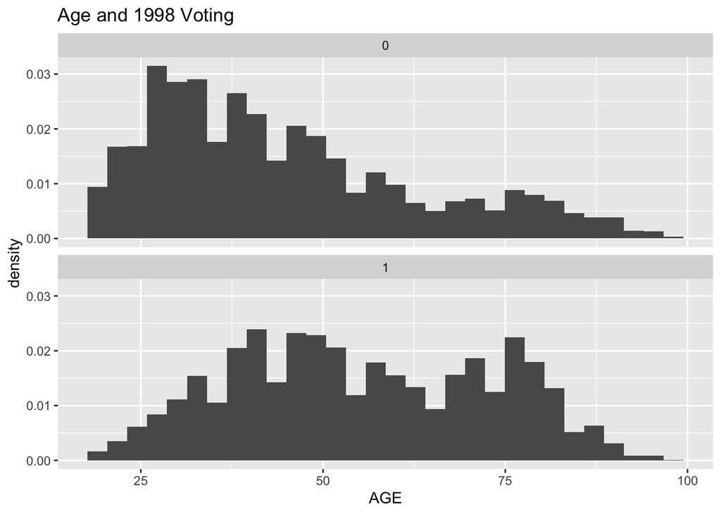

```r
ggplot(turnout) +
  geom_histogram(aes(x=AGE, y=..density.., binwidth=2)) + facet_wrap(~voted1998, nrow=2) + labs(title='Age and 1998 Voting')
```

```r
round(mean(AGE ~ GOTV_call, data=turnout),3)
```

```
##      0      1
## 49.425 58.308
```

```r
t.test(AGE ~ GOTV_call==1, data=turnout)
```

```
##
##  Welch Two Sample t-test
##
## data:  AGE by GOTV_call == 1
## t = -6.9613, df = 256.33, p-value = 2.817e-11
## alternative hypothesis: true difference in means between group FALSE and group TRUE is not equal to 0
## 95 percent confidence interval:
##  -11.395051  -6.369644
## sample estimates:
## mean in group FALSE  mean in group TRUE
##            49.42534            58.30769
```

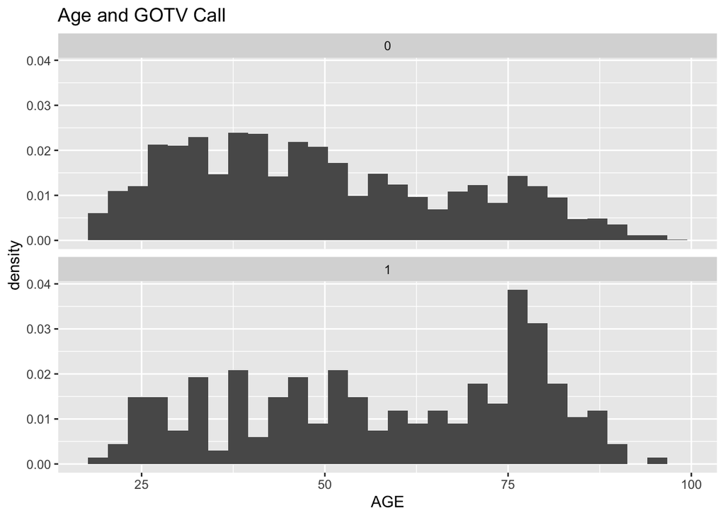

```r
ggplot(turnout) +
  geom_histogram(aes(x=AGE, y=..density.., binwidth=2)) + facet_wrap(~GOTV_call, nrow=2) +
  labs(title='Age and GOTV Call')
```

The mean age of those who voted in 1998 is 55.415 and the mean age of those who did not vote in 1998 is 44.914. The 95% confidence interval for the difference in these two means is -11.182 to -9.821, indicating statistical significance and that age made someone more likely to vote in 1998.

The mean age of those who received a GOTV call is 58.308 and the mean age of those who did not receive a GOTV call is 49.425. The 95% confidence interval for the difference in these two means is -11.395 to -6.370, indicating statistical significance and that age made someone more likely to receive a GOTV call.

Because age increased the likelihood of receiving a GOTV call and the likelihood of voting in 1998, age is a confounding variable.

### Major Party

```r
# major party variable
round(prop(voted1998==1~MAJORPTY, data= turnout),3)
```

```
## prop_TRUE.0 prop_TRUE.1
##       0.350       0.482
```

```r
prop.test(voted1998==1~MAJORPTY, data= turnout)
```

```
##
##  2-sample test for equality of proportions with continuity correction
##
## data:  tally(voted1998 == 1 ~ MAJORPTY)
## X-squared = 144.63, df = 1, p-value < 2.2e-16
## alternative hypothesis: two.sided
## 95 percent confidence interval:
##  -0.1534422 -0.1111651
## sample estimates:
##    prop 1    prop 2
## 0.3501818 0.4824855
```

```r
round(prop(GOTV_call==1~MAJORPTY, data= turnout),3)
```

```
## prop_TRUE.0 prop_TRUE.1
##       0.018       0.025
```

```r
prop.test(GOTV_call==1~MAJORPTY, data= turnout)
```

```
##
##  2-sample test for equality of proportions with continuity correction
##
## data:  tally(GOTV_call == 1 ~ MAJORPTY)
## X-squared = 3.8248, df = 1, p-value = 0.0505
## alternative hypothesis: two.sided
## 95 percent confidence interval:
##  -0.0129180093 -0.0004615944
## sample estimates:
##     prop 1     prop 2
## 0.01781818 0.02450798
```

The proportion of those who voted in 1998 and are not registered for a major party is 0.350 and the sample proportion of those who voted in 1998 and did have a major party registration is 0.482. The 95% confidence interval for the difference in these two proportions is -0.153 to -0.111, indicating statistical significance and that major party registration made someone more likely to vote in 1998.

The proportion of those who received a GOTV call and are not registered for a major party is 0.018 and the sample proportion of those who received a GOTV call and did have a major party registration is 0.025. The 95% confidence interval for the difference in these two proportions is -0.013 to -0.0004, indicating statistical significance and that major party registration made someone more likely to receive a GOTV call.

## Part C

### Evidence that matched dataset is balanced

```r
# Evidence that matched data set is balanced
prop(voted1996 ~ GOTV_call, data= turnout_matched)
```

```
##  prop_1.0  prop_1.1
## 0.7125506 0.7125506
```

```r
prop.test(voted1996 ~ GOTV_call, data= turnout_matched)
```

```
##
##  2-sample test for equality of proportions without continuity correction
##
## data:  tally(voted1996 ~ GOTV_call)
## X-squared = 1.9277e-29, df = 1, p-value = 1
## alternative hypothesis: two.sided
## 95 percent confidence interval:
##  -0.06182709  0.06182709
## sample estimates:
##    prop 1    prop 2
## 0.2874494 0.2874494
```

```r
prop(MAJORPTY ~ GOTV_call, data= turnout_matched)
```

```
##  prop_1.0  prop_1.1
## 0.8072874 0.8016194
```

```r
prop.test(MAJORPTY ~ GOTV_call, data= turnout_matched)
```

```
##
##  2-sample test for equality of proportions with continuity correction
##
## data:  tally(MAJORPTY ~ GOTV_call)
## X-squared = 0.013828, df = 1, p-value = 0.9064
## alternative hypothesis: two.sided
## 95 percent confidence interval:
##  -0.06247690  0.05114086
## sample estimates:
##    prop 1    prop 2
## 0.1927126 0.1983806
```

```r
mean(AGE ~ GOTV_call, data= turnout_matched)
```

```
##        0        1
## 58.26640 58.30769
```

```r
t.test(AGE ~ GOTV_call, data= turnout_matched)
```

```
##
##  Welch Two Sample t-test
##
## data:  AGE by GOTV_call
## t = -0.02987, df = 350.55, p-value = 0.9762
## alternative hypothesis: true difference in means between group 0 and group 1 is not equal to 0
## 95 percent confidence interval:
##  -2.760374  2.677783
## sample estimates:
## mean in group 0 mean in group 1
##        58.26640        58.30769
```

The 95% confidence interval for the difference in proportions of those who voted in 1996 and did receive a call versus those did not receive a call is -0.062 to 0.062. The 95% confidence interval for the difference in mean age of those who did receive a call versus those who did not receive a call is -2.760 to 2.678. All three of these intervals are statistically insignificant because they contain 0 and the matched data set is therefore balanced with respect to the three confounders.

### Repeat of analysis from Part A

```r
# Repeat of analysis from Part A
round(prop(voted1998==1~GOTV_call, data=turnout_matched),3)
```

```
## prop_TRUE.0 prop_TRUE.1
##       0.569       0.648
```

```r
prop.test(voted1998==1~GOTV_call, data=turnout_matched)
```

```
##
##  2-sample test for equality of proportions with continuity correction
##
## data:  tally(voted1998 == 1 ~ GOTV_call)
## X-squared = 4.9027, df = 1, p-value = 0.02682
## alternative hypothesis: two.sided
## 95 percent confidence interval:
##  -0.14663149 -0.01045353
## sample estimates:
##    prop 1    prop 2
## 0.5692308 0.6477733
```

In the matched dataset, the proportion of those receiving a GOTV call who voted in 1998 is 0.648 and the sample proportion of those not receiving a GOTV call who voted in 1998 is 0.569. The 95% confidence interval for the difference in these two proportions is -0.147 to -0.010, indicating statistical significance as the interval does not contain 0. The overall effect of the GOTV call was an increase in the likelihood of voting in the 1998 election. The difference in proportions of 1998 voters who did not receive a call versus those who did is somewhere between -0.147 to -0.010 with 95% confidence.